# Week 2 Application Exercise - KEY

Prof. Amanda D. Perez, PhD

# AE 3: Star Wars + Data Visualization

### Glimpse at the starwars data frame.

```r
glimpse(starwars)
```

```
## Rows: 87
## Columns: 14
## $ name       <chr> "Luke Skywalker", "C-3PO", "R2-D2", "Darth Vader", "Leia Or…
## $ height     <int> 172, 167, 96, 202, 150, 178, 165, 97, 183, 182, 188, 180, 2…
## $ mass       <dbl> 77.0, 75.0, 32.0, 136.0, 49.0, 120.0, 75.0, 32.0, 84.0, 77.…
## $ hair_color <chr> "blond", NA, NA, "none", "brown", "brown, grey", "brown", N…
## $ skin_color <chr> "fair", "gold", "white, blue", "white", "light", "light", "…
## $ eye_color  <chr> "blue", "yellow", "red", "yellow", "brown", "blue", "blue",…
## $ birth_year <dbl> 19.0, 112.0, 33.0, 41.9, 19.0, 52.0, 47.0, NA, 24.0, 57.0, …
## $ sex        <chr> "male", "none", "none", "male", "female", "male", "female",…
## $ gender     <chr> "masculine", "masculine", "masculine", "masculine", "femini…
## $ homeworld  <chr> "Tatooine", "Tatooine", "Naboo", "Tatooine", "Alderaan", "T…
## $ species    <chr> "Human", "Droid", "Droid", "Human", "Human", "Human", "Huma…
## $ films      <list> <"The Empire Strikes Back", "Revenge of the Sith", "Return…
## $ vehicles   <list> <"Snowspeeder", "Imperial Speeder Bike">, <>, <>, <>, "Imp…
## $ starships  <list> <"X-wing", "Imperial shuttle">, <>, <>, "TIE Advanced x1",…
```

### Modify the following plot to change the color of all points to `"pink"`.

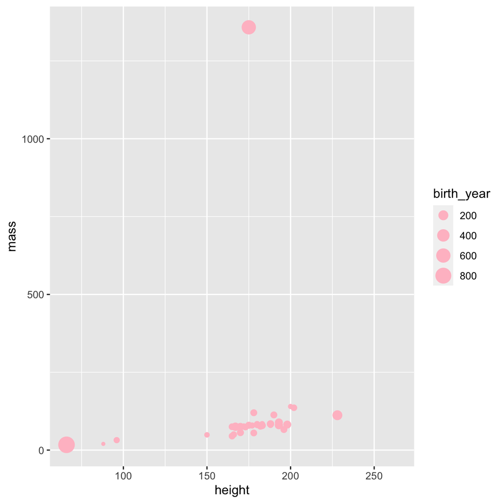

```r
ggplot(starwars,
       aes(x = height, y = mass, color = gender, size = birth_year)) +
  geom_point(color = "pink")
```

### Add labels for title, x and y axes, and size of points. Uncomment to see the effect.

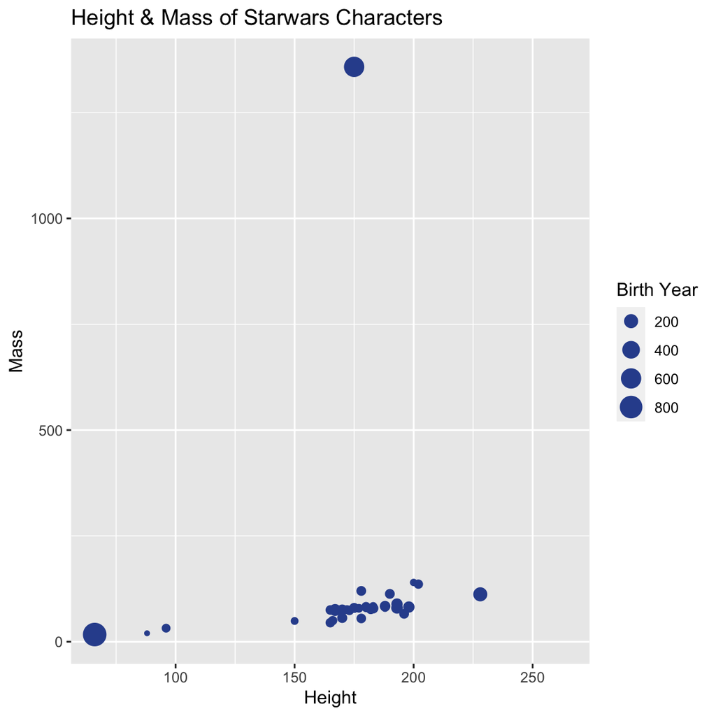

```r
library(viridis)
ggplot(starwars,
       aes(x = height, y = mass, color = gender, size = birth_year)) +
  geom_point(color = "#30509C") +
  labs(
    title = "Height & Mass of Starwars Characters",
    x = "Height",
    y = "Mass",
    size = "Birth Year"
    )
```

### Pick a single categorical variable from the data set and make a bar plot of its distribution.

(A little bit of starter code is provided below, and the code chunk is set to not be evaluated with `eval = FALSE` because the current code in there is not valid code and hence the document wouldn’t knit. Once you replace the code with valid code, set the chunk option to `eval = TRUE`, or remove the `eval` option altogether since it’s set to `TRUE` by default.)

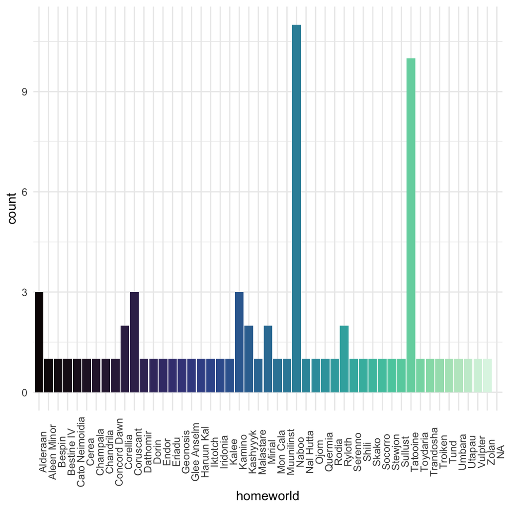

```r
ggplot(starwars, aes(homeworld, fill = homeworld)) +
  geom_bar() +
  theme(axis.text.y =element_text(size=10))+
  scale_fill_viridis_d(option = "mako") +
  guides(fill = "none") +
  theme_minimal() +
  theme(axis.text.x = element_text(angle = 90))
```

### Pick a single numerical variable and make a histogram of it.

(This time no starter code is provided, you’re on your own!)

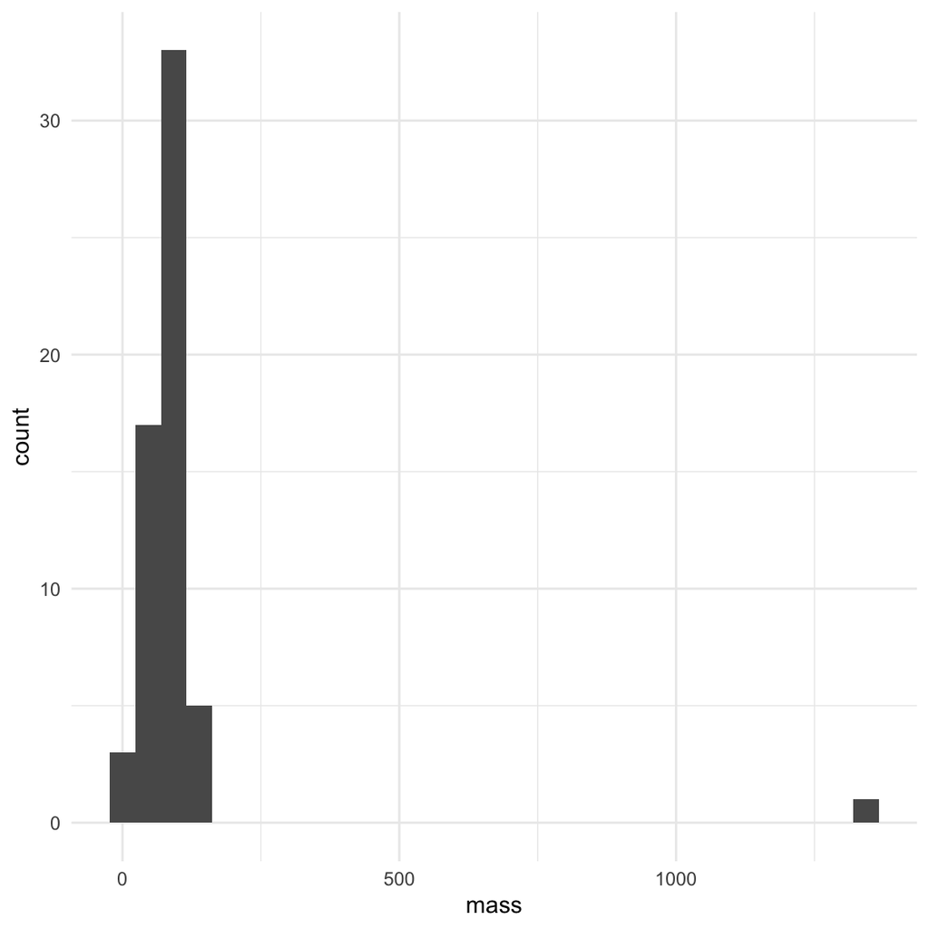

```r
ggplot(starwars, aes(mass)) +
  geom_histogram() +
  theme_minimal()
```

### Pick a numerical variable and a categorical variable and make a visualisation (you pick the type!) to visualise the relationship between the two variables. Along with your code and output, provide an interpretation of the visualisation.

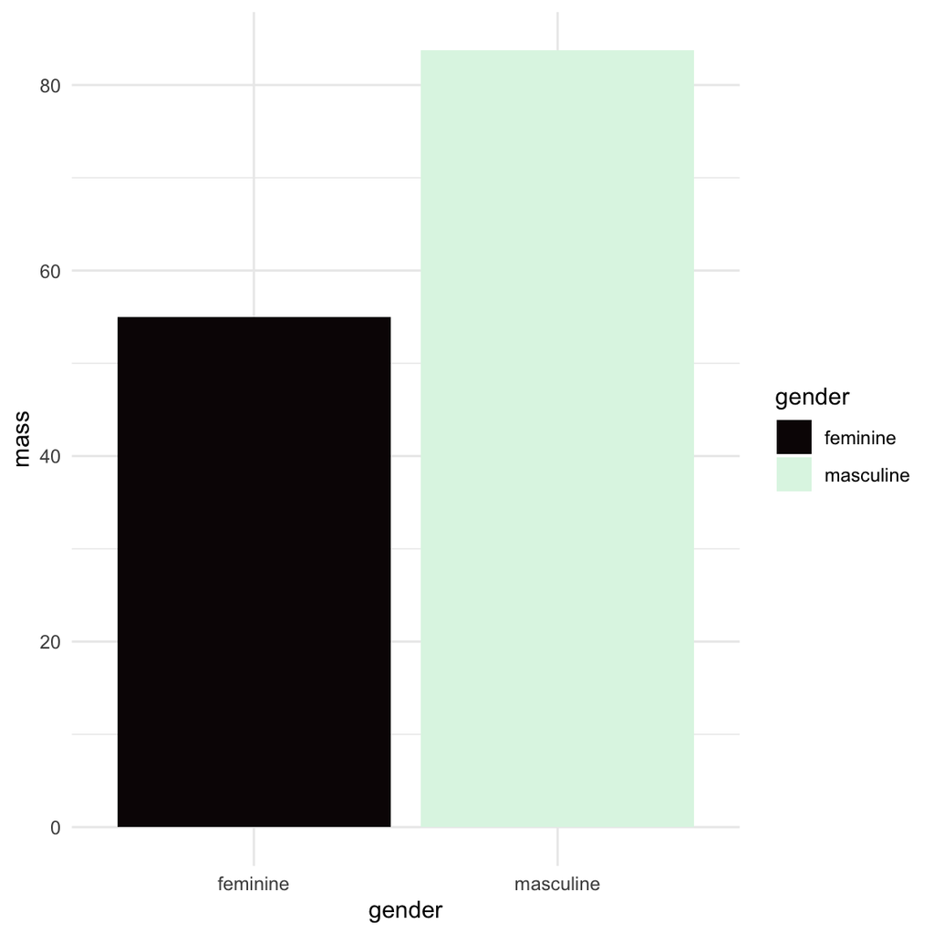

```r
ggplot(na.omit(starwars), aes(gender, mass, fill = gender)) +
  stat_summary(fun = "mean", geom = "bar") +
  scale_fill_viridis_d(option = "mako") +
  theme_minimal()
```

### Pick two numerical variables and two categorical variables and make a visualisation that incorportes all of them and provide an interpretation with your answer.

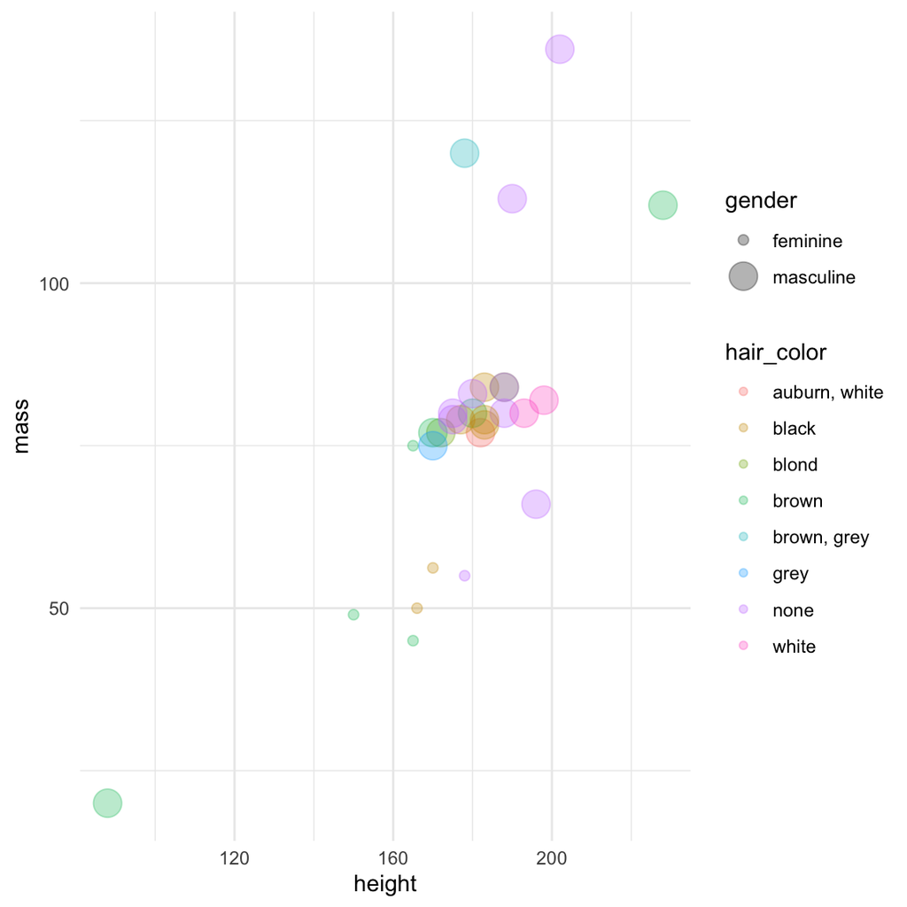

```r
ggplot(na.omit(starwars),(aes(x = height, y = mass, size = gender, color = hair_color))) +
  geom_point(alpha = 0.3) +
  theme_minimal()
```

# AE 4: Hotels + Data Wrangling

```r
library(tidyverse)
library(skimr)
```

```r
# From TidyTuesday: https://github.com/rfordatascience/tidytuesday/blob/master/data/2020/2020-02-11/readme.md
hotels <- read_csv("https://raw.githubusercontent.com/rfordatascience/tidytuesday/master/data/2020/2020-02-11/hotels.csv")
```

## Exercises

### Exercise 1.

Warm up! Take a look at an overview of the data with the `skim()` function.

```r
skim(hotels)
```

Data summary

| Name | hotels |
| --- | --- |
| Number of rows | 119390 |
| Number of columns | 32 |
| _______________________ |  |
| Column type frequency: |  |
| character | 13 |
| Date | 1 |
| numeric | 18 |
| ________________________ |  |
| Group variables | None |

**Variable type: character**

| skim_variable | n_missing | complete_rate | min | max | empty | n_unique | whitespace |
| --- | --- | --- | --- | --- | --- | --- | --- |
| hotel | 0 | 1 | 10 | 12 | 0 | 2 | 0 |
| arrival_date_month | 0 | 1 | 3 | 9 | 0 | 12 | 0 |
| meal | 0 | 1 | 2 | 9 | 0 | 5 | 0 |
| country | 0 | 1 | 2 | 4 | 0 | 178 | 0 |
| market_segment | 0 | 1 | 6 | 13 | 0 | 8 | 0 |
| distribution_channel | 0 | 1 | 3 | 9 | 0 | 5 | 0 |
| reserved_room_type | 0 | 1 | 1 | 1 | 0 | 10 | 0 |
| assigned_room_type | 0 | 1 | 1 | 1 | 0 | 12 | 0 |
| deposit_type | 0 | 1 | 10 | 10 | 0 | 3 | 0 |
| agent | 0 | 1 | 1 | 4 | 0 | 334 | 0 |
| company | 0 | 1 | 1 | 4 | 0 | 353 | 0 |
| customer_type | 0 | 1 | 5 | 15 | 0 | 4 | 0 |
| reservation_status | 0 | 1 | 7 | 9 | 0 | 3 | 0 |

**Variable type: Date**

| skim_variable | n_missing | complete_rate | min | max | median | n_unique |
| --- | --- | --- | --- | --- | --- | --- |
| reservation_status_date | 0 | 1 | 2014-10-17 | 2017-09-14 | 2016-08-07 | 926 |

**Variable type: numeric**

| skim_variable | n_missing | complete_rate | mean | sd | p0 | p25 | p50 | p75 | p100 | hist |
| --- | --- | --- | --- | --- | --- | --- | --- | --- | --- | --- |
| is_canceled | 0 | 1 | 0.37 | 0.48 | 0.00 | 0.00 | 0.00 | 1 | 1 | ▇▁▁▁▅ |
| lead_time | 0 | 1 | 104.01 | 106.86 | 0.00 | 18.00 | 69.00 | 160 | 737 | ▇▂▁▁▁ |
| arrival_date_year | 0 | 1 | 2016.16 | 0.71 | 2015.00 | 2016.00 | 2016.00 | 2017 | 2017 | ▃▁▇▁▆ |
| arrival_date_week_number | 0 | 1 | 27.17 | 13.61 | 1.00 | 16.00 | 28.00 | 38 | 53 | ▅▇▇▇▅ |
| arrival_date_day_of_month | 0 | 1 | 15.80 | 8.78 | 1.00 | 8.00 | 16.00 | 23 | 31 | ▇▇▇▇▆ |
| stays_in_weekend_nights | 0 | 1 | 0.93 | 1.00 | 0.00 | 0.00 | 1.00 | 2 | 19 | ▇▁▁▁▁ |
| stays_in_week_nights | 0 | 1 | 2.50 | 1.91 | 0.00 | 1.00 | 2.00 | 3 | 50 | ▇▁▁▁▁ |
| adults | 0 | 1 | 1.86 | 0.58 | 0.00 | 2.00 | 2.00 | 2 | 55 | ▇▁▁▁▁ |
| children | 4 | 1 | 0.10 | 0.40 | 0.00 | 0.00 | 0.00 | 0 | 10 | ▇▁▁▁▁ |
| babies | 0 | 1 | 0.01 | 0.10 | 0.00 | 0.00 | 0.00 | 0 | 10 | ▇▁▁▁▁ |
| is_repeated_guest | 0 | 1 | 0.03 | 0.18 | 0.00 | 0.00 | 0.00 | 0 | 1 | ▇▁▁▁▁ |
| previous_cancellations | 0 | 1 | 0.09 | 0.84 | 0.00 | 0.00 | 0.00 | 0 | 26 | ▇▁▁▁▁ |
| previous_bookings_not_canceled | 0 | 1 | 0.14 | 1.50 | 0.00 | 0.00 | 0.00 | 0 | 72 | ▇▁▁▁▁ |
| booking_changes | 0 | 1 | 0.22 | 0.65 | 0.00 | 0.00 | 0.00 | 0 | 21 | ▇▁▁▁▁ |
| days_in_waiting_list | 0 | 1 | 2.32 | 17.59 | 0.00 | 0.00 | 0.00 | 0 | 391 | ▇▁▁▁▁ |
| adr | 0 | 1 | 101.83 | 50.54 | -6.38 | 69.29 | 94.58 | 126 | 5400 | ▇▁▁▁▁ |
| required_car_parking_spaces | 0 | 1 | 0.06 | 0.25 | 0.00 | 0.00 | 0.00 | 0 | 8 | ▇▁▁▁▁ |
| total_of_special_requests | 0 | 1 | 0.57 | 0.79 | 0.00 | 0.00 | 0.00 | 1 | 5 | ▇▁▁▁▁ |

### Exercise 2.

Are people traveling on a whim? Let’s see…

Fill in the blanks for filtering for hotel bookings where the guest is **not** from the US (`country` code `"USA"`) and the `lead_time` is less than 1 day.

**Note:** You will need to set `eval=TRUE` when you have an answer you want to try out.

```r
hotels %>%
  filter(
    country != "USA",
    lead_time < 1
    )
```

```
## # A tibble: 6,174 x 32
##    hotel        is_canceled lead_time arrival_date_year arrival_date_month
##    <chr>              <dbl>     <dbl>             <dbl> <chr>
##  1 Resort Hotel           0         0              2015 July
##  2 Resort Hotel           0         0              2015 July
##  3 Resort Hotel           0         0              2015 July
##  4 Resort Hotel           0         0              2015 July
##  5 Resort Hotel           0         0              2015 July
##  6 Resort Hotel           0         0              2015 July
##  7 Resort Hotel           0         0              2015 July
##  8 Resort Hotel           0         0              2015 July
##  9 Resort Hotel           0         0              2015 July
## 10 Resort Hotel           0         0              2015 July
## # … with 6,164 more rows, and 27 more variables:
## #   arrival_date_week_number <dbl>, arrival_date_day_of_month <dbl>,
## #   stays_in_weekend_nights <dbl>, stays_in_week_nights <dbl>, adults <dbl>,
## #   children <dbl>, babies <dbl>, meal <chr>, country <chr>,
## #   market_segment <chr>, distribution_channel <chr>, is_repeated_guest <dbl>,
## #   previous_cancellations <dbl>, previous_bookings_not_canceled <dbl>,
## #   reserved_room_type <chr>, assigned_room_type <chr>, booking_changes <dbl>,
## #   deposit_type <chr>, agent <chr>, company <chr>, days_in_waiting_list <dbl>,
## #   customer_type <chr>, adr <dbl>, required_car_parking_spaces <dbl>,
## #   total_of_special_requests <dbl>, reservation_status <chr>,
## #   reservation_status_date <date>
```

### Exercise 3.

How many bookings involve at least 1 child **or** baby?

In the following chunk, replace

- `[AT LEAST]` with the logical operator for “at least” (in two places)
- `[OR]` with the logical operator for “or”

**Note:** You will need to set `eval=TRUE` when you have an answer you want to try out.

```r
hotels %>%
  filter(
    children >= 1 | babies >= 1
    )
```

```
## # A tibble: 9,332 x 32
##    hotel        is_canceled lead_time arrival_date_year arrival_date_month
##    <chr>              <dbl>     <dbl>             <dbl> <chr>
##  1 Resort Hotel           0        18              2015 July
##  2 Resort Hotel           1        47              2015 July
##  3 Resort Hotel           0         1              2015 July
##  4 Resort Hotel           0        10              2015 July
##  5 Resort Hotel           1        79              2015 July
##  6 Resort Hotel           0       101              2015 July
##  7 Resort Hotel           0        92              2015 July
##  8 Resort Hotel           1        26              2015 July
##  9 Resort Hotel           0       102              2015 July
## 10 Resort Hotel           0        78              2015 July
## # … with 9,322 more rows, and 27 more variables:
## #   arrival_date_week_number <dbl>, arrival_date_day_of_month <dbl>,
## #   stays_in_weekend_nights <dbl>, stays_in_week_nights <dbl>, adults <dbl>,
## #   children <dbl>, babies <dbl>, meal <chr>, country <chr>,
## #   market_segment <chr>, distribution_channel <chr>, is_repeated_guest <dbl>,
## #   previous_cancellations <dbl>, previous_bookings_not_canceled <dbl>,
## #   reserved_room_type <chr>, assigned_room_type <chr>, booking_changes <dbl>,
## #   deposit_type <chr>, agent <chr>, company <chr>, days_in_waiting_list <dbl>,
## #   customer_type <chr>, adr <dbl>, required_car_parking_spaces <dbl>,
## #   total_of_special_requests <dbl>, reservation_status <chr>,
## #   reservation_status_date <date>
```

### Exercise 4.

Do you think it’s more likely to find bookings with children or babies in city hotels or resort hotels? Test your intuition. Using `filter()` determine the number of bookings in resort hotels that have more than 1 child **or** baby in the room? Then, do the same for city hotels, and compare the numbers of rows in the resulting filtered data frames.

```r
hotels %>%
  filter(
    hotel == "Resort Hotel",
    children > 1 | babies > 1
    ) %>%
  count()
```

```
## # A tibble: 1 x 1
##       n
##   <int>
## 1  1655
```

```r
hotels %>%
  filter(
    hotel == "City Hotel",
    children > 1 | babies > 1
    ) %>%
  count()
```

```
## # A tibble: 1 x 1
##       n
##   <int>
## 1  2091
```

### Exercise 5.

Create a frequency table of the number of `adults` in a booking. Display the results in descending order so the most common observation is on top. What is the most common number of adults in bookings in this dataset? Are there any surprising results?

**Note:** Don’t forget to label your R chunk as well (where it says `label-me-1`). Your label should be short, informative, and shouldn’t include spaces. It also shouldn’t repeat a previous label, otherwise R Markdown will give you an error about repeated R chunk labels.

```r
hotels %>%
  count(adults) %>%
  arrange(desc(n))
```

```
## # A tibble: 14 x 2
##    adults     n
##     <dbl> <int>
##  1      2 89680
##  2      1 23027
##  3      3  6202
##  4      0   403
##  5      4    62
##  6     26     5
##  7      5     2
##  8     20     2
##  9     27     2
## 10      6     1
## 11     10     1
## 12     40     1
## 13     50     1
## 14     55     1
```

### Exercise 6.

Repeat Exercise 5, once for canceled bookings (`is_canceled` coded as 1) and once for not canceled bookings (`is_canceled` coded as 0). What does this reveal about the surprising results you spotted in the previous exercise?

**Note:** Don’t forget to label your R chunk as well (where it says `label-me-2`).

```r
hotels %>%
  filter(is_canceled == 0) %>%
  count(adults) %>%
  arrange(desc(n))
```

```
## # A tibble: 5 x 2
##   adults     n
##    <dbl> <int>
## 1      2 54422
## 2      1 16353
## 3      3  4051
## 4      0   294
## 5      4    46
```

```r
hotels %>%
  filter(is_canceled == 1) %>%
  count(adults) %>%
  arrange(desc(n))
```

```
## # A tibble: 14 x 2
##    adults     n
##     <dbl> <int>
##  1      2 35258
##  2      1  6674
##  3      3  2151
##  4      0   109
##  5      4    16
##  6     26     5
##  7      5     2
##  8     20     2
##  9     27     2
## 10      6     1
## 11     10     1
## 12     40     1
## 13     50     1
## 14     55     1
```

### Exercise 7.

Calculate minimum, mean, median, and maximum average daily rate (`adr`) grouped by `hotel` type so that you can get these statistics separately for resort and city hotels. Which type of hotel is higher, on average?

```r
hotels %>%
  group_by(hotel) %>%
  summarize(Min  = min(adr),
            Max = max(adr),
            Mean = mean(adr),
            Median = median(adr))
```

```
## # A tibble: 2 x 5
##   hotel          Min   Max  Mean Median
##   <chr>        <dbl> <dbl> <dbl>  <dbl>
## 1 City Hotel    0     5400 105.    99.9
## 2 Resort Hotel -6.38   508  95.0   75
```

### Exercise 8.

We observe two unusual values in the summary statistics above – a negative minimum, and a very high maximum). What types of hotels are these? Locate these observations in the dataset and find out the arrival date (year and month) as well as how many people (adults, children, and babies) stayed in the room. You can investigate the data in the viewer to locate these values, but preferably you should identify them in a reproducible way with some code.

**Hint:** For example, you can `filter` for the given `adr` amounts and `select` the relevant columns.

```r
hotels %>%
  filter(
    adr == -6.38 |
    adr == 5400
  ) %>%
  select(arrival_date_month, arrival_date_year, adults, children, babies)
```

```
## # A tibble: 2 x 5
##   arrival_date_month arrival_date_year adults children babies
##   <chr>                          <dbl>  <dbl>    <dbl>  <dbl>
## 1 March                           2017      2        0      0
## 2 March                           2016      2        0      0
```

## References

1. Mine Çetinkaya-Rundel; Creator